Rapport sur l’étude de la ville de Pontault-Combault

# Bien-être et végétalisation

[interactive table not shown]

## Présentation et analyse

### Introduction

Le projet BENEV vise à identifier les zones prioritaires de revégétalisation dans la ville de Pontault-Combault. Pour ce faire, nous étudions la perception de nature et son incidence sur le bien-être des résidents en ville. Ce rapport présente les analyses effectuées à partir des données collectées auprès des habitants de Pontault-Combault.

### Analyse du profil des répondants

**4000 citoyens** résidant en ville ont complété le questionnaire entre le 1er octobre et le 20 décembre 2024. Voici leurs statistiques descriptives.

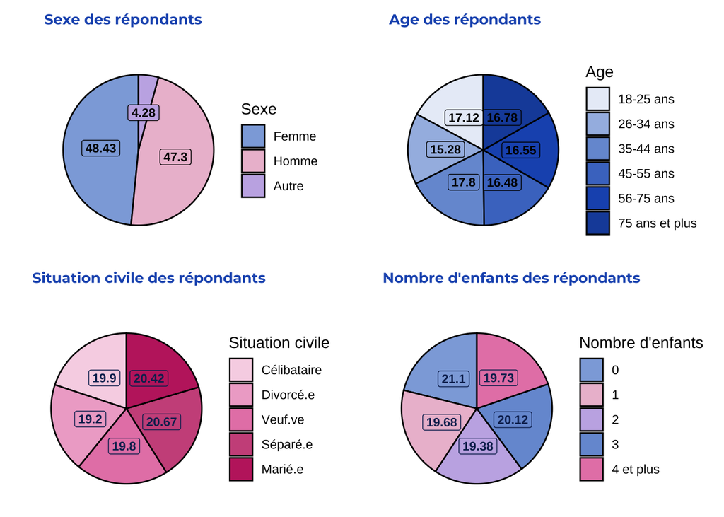

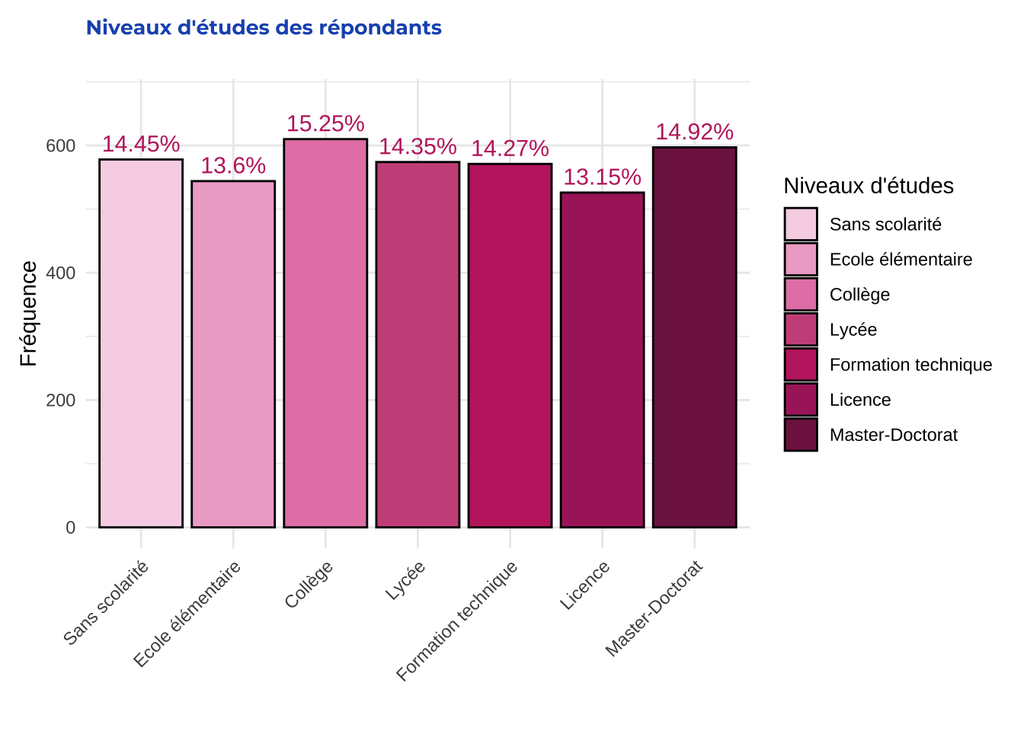

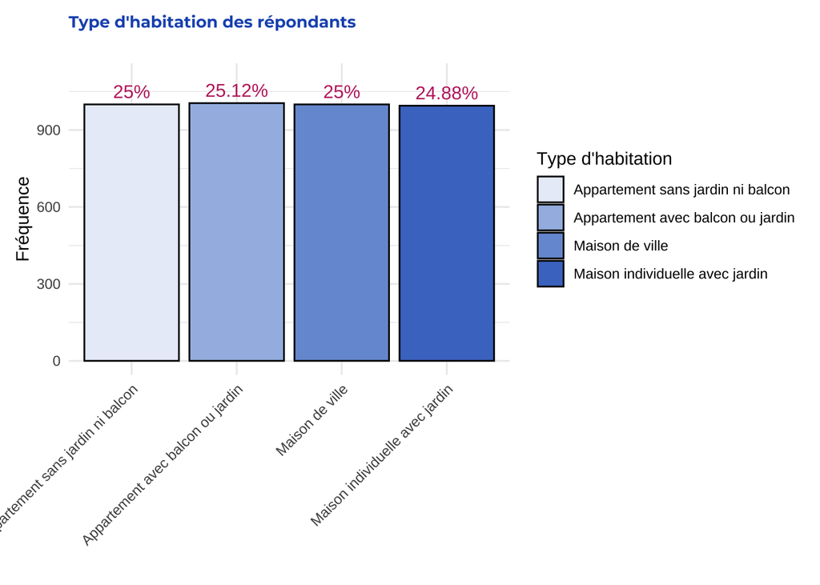

### Niveaux de bien-être et perception de nature

Les tableaux ci-dessous présentent les niveaux de bien-être et de perception de nature des habitants de Pontault-Combault. Nous mettons également en évidence l’existence de différences significatives avec notre échantillon national. Ainsi la moyenne pour notre échantillon national apparaît entre parenthèses lorsqu’elle est significativement différente de la moyenne des habitants de Pontault-Combault.

## Niveaux de bien-être

Nous avons interrogé les résidents sur leur niveau de bien-être au cours de la dernière semaine dans leur lieu de résidence. L’échelle de bien-être que nous utilisons permet d’obtenir une note de bien-être global et de distinguer les facettes suivantes : le bien-être psychologique, physique, lié à l’environnement (perception que l’on vit dans un environnement sain et satisfaisant) et lié aux ressources (satisfaction quant à notre capacité à nous déplacer, à pratiquer des loisirs, à accéder aux informations). Plus les notes sont élevées, plus les résidents ont des niveaux de bien-être élevés.

|  | Critère | Note moyenne |
| --- | --- | --- |
| 1 | Bien-être global | 3.08 (3.22) |
| 2 | Bien-être psychologique | 3.12 (3.32) |
| 3 | Bien-être environnemental | 3.06 (3.14) |
| 4 | Bien-être physique | 3.01 |
| 5 | Bien-être ressources | 3.09 (3.27) |

Entre parenthèses sont présentées les moyennes à l’échelle nationale. La note minimale théorique est 1 et la note maximale théorique est 5.

## Perception de nature autour du lieu de résidence

Nous avons interrogé les résidents sur les types d’espaces verts et de nature à proximité de leur lieu de résidence (qu’ils voient de chez eux ou auquel ils ont accès en moins de 15 min à pied). Ces types d’espaces verts sont catégorisés en trois dimensions : la nature de proximité comme les parterres de fleurs et les toits végétalisés ; la nature domestiquée comme les parcs et jardins publics et la nature non-domestiquée comme les bois, les prairies. Plus les notes sont élevées, plus les résidents ont accès à ces types de nature autour de leur lieu de résidence.

|  | Critère | Note moyenne |
| --- | --- | --- |
| 1 | Perception de nature globale | 2.85 (2.61) |
| 2 | Perception de nature non-domestiquée | 2.89 (2.73) |
| 3 | Perception de nature domestiquée | 3 |
| 4 | Perception de nature de proximité | 2.72 (2.26) |
| 5 | Fréquence d'exposition à la nature | 3.1 (3.29) |
| 6 | Perception de biodiversité | 2.23 (1) |

Entre parenthèses sont présentées les moyennes à l’échelle nationale. La note minimale théorique est 1 et la note maximale théorique est 5.

## Caractéristiques des lieux de nature autour du lieu de résidence

Nous avons interrogé les résidents sur leur satisfaction concernant certaines caractéristiques des environnements naturels à proximité de leur lieu de résidence. Plus les notes sont élevées, plus les résidents sont satisfaits de ces caractéristiques.

|  | Critère | Note moyenne |
| --- | --- | --- |
| 1 | La sécurité | 3.17 (3.48) |
| 2 | La propreté | 3.18 (3.42) |
| 3 | L’esthétique, la beauté des lieux | 3.25 (3.66) |
| 4 | Le coût (coût d’accès, d’entretien) | 3.26 (3.61) |
| 5 | Les horaires d’ouverture | 3.3 (3.74) |
| 6 | La signalétique | 3.17 (3.47) |
| 7 | La facilité d’accès | 3.31 (3.84) |
| 8 | Les espaces de mobilité | 3.22 (3.54) |
| 9 | Les espaces ou installations permettant le repos | 3.2 (3.49) |
| 10 | Les espaces ou installations permettant le loisir | 3.2 (3.45) |

Entre parenthèses sont présentées les moyennes à l’échelle nationale. La note minimale théorique est 1 et la note maximale théorique est 5.

## Activités dans la nature

Nous avons interrogé les résidents sur la fréquence à laquelle ils effectuaient certaines activités dans la nature à proximité de le lieu de résidence. Ces activités sont regroupées en activités sociales et/ou calmes et activités sportives. Plus les notes sont élevées, plus les résidents effectuent fréquemment ces activités dans les lieux de nature autour de chez eux.

|  | Critère | Note moyenne |
| --- | --- | --- |
| 1 | Fréquence d'activités globales | 2.81 (2.52) |
| 2 | Fréquence d'activités sociales et/ou calmes | 2.88 (2.69) |
| 3 | Fréquence d'activités sportives | 2.56 (1.9) |

Entre parenthèses sont présentées les moyennes à l’échelle nationale. La note minimale théorique est 1 et la note maximale théorique est 5.

### Exemple d’analyse approfondie : Niveaux de bien-être et perception de nature en fonction des caractéristiques de la population

|  | Revenu du foyer | Critère Bien-Être Global | Différence Estimée | p-value |
| --- | --- | --- | --- | --- |
| 1 | Moins de 17 999 € | 2.98 | -0.01 | 0.353 |
| 2 | Plus de 51 000 € | 2.99 | -0.01 | 0.353 |

## Données cartographiques de Pontault-Combault

Cacher les infos en dessous des couleurs

**Cartographie générale**

## Conclusion

Concernant le type de végétalisation, la nature est principalement de type domestiqué actuellement. La création de zones de nature moins domestiquée telles que des parterres autonomes, des friches urbaines, des plantes sauvages pourrait enrichir la biodiversité et stimuler la perception des résidents d’une nature complémentaire.